# Assignment 02

Ann-Sophie Frind

2024-03-02

# Preparations

```r
suppressPackageStartupMessages({ # gets rid of printing all the unnecessary info
  library(AnnotationHub) # to fetch genomes, annotations, etc.
  library(ensembldb)     # to manipulate ensembl gene annotations
  library(GenomicRanges) # data structure for genomic ranges
  library(epiwraps)      # visualization
})
```

# 1 Using AnnotationHub, find and download the following annotations data:

Info for myself: Ensembl serves as the primary database for storing and accessing genomic annotation data, while EnsDb provides a convenient way to access and work with Ensembl’s annotation data within the R programming environment. EnsDb packages leverage the wealth of genomic annotation information available in Ensembl, allowing R users to seamlessly incorporate Ensembl data into their genomic analyses and workflows. EnsDb (Ensembl Annotation Database) is a specific component within the Ensembl project that provides programmatic access to Ensembl’s genomic annotation data within the R environment.

## 1.1 The mouse (Mus Musculus) EnsDb object, version 102, genome build GRCm38

```r
ah <- AnnotationHub() # just shortens the name (?)
q1 <- query(ah,c("EnsDb", "Mus musculus", "version 102", "GRCm38"))
q1 # output to find the specific resource ID, --> AH89211
```

```
## AnnotationHub with 1 record
## # snapshotDate(): 2023-10-23
## # names(): AH89211
## # $dataprovider: Ensembl
## # $species: Mus musculus
## # $rdataclass: EnsDb
## # $rdatadateadded: 2020-10-27
## # $title: Ensembl 102 EnsDb for Mus musculus
## # $description: Gene and protein annotations for Mus musculus based on Ensem...
## # $taxonomyid: 10090
## # $genome: GRCm38
## # $sourcetype: ensembl
## # $sourceurl: http://www.ensembl.org
## # $sourcesize: NA
## # $tags: c("102", "AHEnsDbs", "Annotation", "EnsDb", "Ensembl", "Gene",
## #   "Protein", "Transcript")
## # retrieve record with 'object[["AH89211"]]'
```

```r
# Download data
musm <- ah[["AH89211"]] # downloads the according annotation data (number retrieved from q1)
```

```
## loading from cache
```

```r
musm
```

```
## EnsDb for Ensembl:
## |Backend: SQLite
## |Db type: EnsDb
## |Type of Gene ID: Ensembl Gene ID
## |Supporting package: ensembldb
## |Db created by: ensembldb package from Bioconductor
## |script_version: 0.3.6
## |Creation time: Sun Dec 20 12:15:16 2020
## |ensembl_version: 102
## |ensembl_host: localhost
## |Organism: Mus musculus
## |taxonomy_id: 10090
## |genome_build: GRCm38
## |DBSCHEMAVERSION: 2.1
## | No. of genes: 56305.
## | No. of transcripts: 144778.
## |Protein data available.
```

## 1.2 The mouse genome sequence ( dna_sm ) in TwoBit/2bit format for GRCm38

```r
q2 <- query(ah,c("dna_sm", "TwoBit", "GRCm38")) # "dna_sm" = a filter term to search for specific DNA sequences
q2 # --> newest: AH88477
```

```
## AnnotationHub with 19 records
## # snapshotDate(): 2023-10-23
## # $dataprovider: Ensembl
## # $species: Mus musculus, mus musculus
## # $rdataclass: TwoBitFile
## # additional mcols(): taxonomyid, genome, description,
## #   coordinate_1_based, maintainer, rdatadateadded, preparerclass, tags,
## #   rdatapath, sourceurl, sourcetype
## # retrieve records with, e.g., 'object[["AH49775"]]'
##
##             title
##   AH49775 | Mus_musculus.GRCm38.dna_sm.primary_assembly.2bit
##   AH50120 | Mus_musculus.GRCm38.dna_sm.primary_assembly.2bit
##   AH50611 | Mus_musculus.GRCm38.dna_sm.primary_assembly.2bit
##   AH51299 | Mus_musculus.GRCm38.dna_sm.primary_assembly.2bit
##   AH51645 | Mus_musculus.GRCm38.dna_sm.primary_assembly.2bit
##   ...       ...
##   AH70177 | Mus_musculus.GRCm38.dna_sm.primary_assembly.2bit
##   AH77927 | Mus_musculus.GRCm38.dna_sm.primary_assembly.2bit
##   AH82549 | Mus_musculus.GRCm38.dna_sm.primary_assembly.2bit
##   AH84787 | Mus_musculus.GRCm38.dna_sm.primary_assembly.2bit
##   AH88477 | Mus_musculus.GRCm38.dna_sm.primary_assembly.2bit
```

```r
# download data
mus2b <- ah[["AH88477"]]
```

```
## loading from cache
```

```
## require("rtracklayer")
```

```r
mus2b
```

```
## TwoBitFile object
## resource: /Users/ann-sophiefrind/Library/Caches/org.R-project.R/R/AnnotationHub/6e6a35466b51_95223
```

## 1.3 The drosophila melanogaster genome sequence ( dna_sm ) in TwoBit/2bit format for BDGP6

```r
q3 <- query(ah,c("dna_sm", "TwoBit", "BDGP6"))
q3 # --> newest: AH106160
```

```
## AnnotationHub with 24 records
## # snapshotDate(): 2023-10-23
## # $dataprovider: Ensembl
## # $species: Drosophila melanogaster, drosophila melanogaster
## # $rdataclass: TwoBitFile
## # additional mcols(): taxonomyid, genome, description,
## #   coordinate_1_based, maintainer, rdatadateadded, preparerclass, tags,
## #   rdatapath, sourceurl, sourcetype
## # retrieve records with, e.g., 'object[["AH49674"]]'
##
##              title
##   AH49674  | Drosophila_melanogaster.BDGP6.dna_sm.toplevel.2bit
##   AH50019  | Drosophila_melanogaster.BDGP6.dna_sm.toplevel.2bit
##   AH50510  | Drosophila_melanogaster.BDGP6.dna_sm.toplevel.2bit
##   AH51198  | Drosophila_melanogaster.BDGP6.dna_sm.toplevel.2bit
##   AH51544  | Drosophila_melanogaster.BDGP6.dna_sm.toplevel.2bit
##   ...        ...
##   AH90691  | Drosophila_melanogaster.BDGP6.32.dna_sm.toplevel.2bit
##   AH92960  | Drosophila_melanogaster.BDGP6.32.dna_sm.toplevel.2bit
##   AH99424  | Drosophila_melanogaster.BDGP6.32.dna_sm.toplevel.2bit
##   AH103729 | Drosophila_melanogaster.BDGP6.32.dna_sm.toplevel.2bit
##   AH106160 | Drosophila_melanogaster.BDGP6.32.dna_sm.toplevel.2bit
```

```r
# download data
dm2b <- ah[["AH106160"]]
```

```
## loading from cache
```

```r
dm2b
```

```
## TwoBitFile object
## resource: /Users/ann-sophiefrind/Library/Caches/org.R-project.R/R/AnnotationHub/6e6a222fae2a_112906
```

# 2 Using the mouse EnsDb, find the following:

## 2.1 How many different ensembl gene IDs and gene symbols are there for protein-coding genes?

```r
g <- genes(musm) # genes() gives a table with gene_id, symbol and other columns
head(g)
```

```
## GRanges object with 6 ranges and 9 metadata columns:
##                      seqnames          ranges strand |            gene_id
##                         <Rle>       <IRanges>  <Rle> |        <character>
##   ENSMUSG00000102693        1 3073253-3074322      + | ENSMUSG00000102693
##   ENSMUSG00000064842        1 3102016-3102125      + | ENSMUSG00000064842
##   ENSMUSG00000051951        1 3205901-3671498      - | ENSMUSG00000051951
##   ENSMUSG00000102851        1 3252757-3253236      + | ENSMUSG00000102851
##   ENSMUSG00000103377        1 3365731-3368549      - | ENSMUSG00000103377
##   ENSMUSG00000104017        1 3375556-3377788      - | ENSMUSG00000104017
##                          gene_name         gene_biotype seq_coord_system
##                        <character>          <character>      <character>
##   ENSMUSG00000102693 4933401J01Rik                  TEC       chromosome
##   ENSMUSG00000064842       Gm26206                snRNA       chromosome
##   ENSMUSG00000051951          Xkr4       protein_coding       chromosome
##   ENSMUSG00000102851       Gm18956 processed_pseudogene       chromosome
##   ENSMUSG00000103377       Gm37180                  TEC       chromosome
##   ENSMUSG00000104017       Gm37363                  TEC       chromosome
##                                 description      gene_id_version
##                                 <character>          <character>
##   ENSMUSG00000102693 RIKEN cDNA 4933401J0.. ENSMUSG00000102693.1
##   ENSMUSG00000064842 predicted gene, 2620.. ENSMUSG00000064842.1
##   ENSMUSG00000051951 X-linked Kx blood gr.. ENSMUSG00000051951.5
##   ENSMUSG00000102851 predicted gene, 1895.. ENSMUSG00000102851.1
##   ENSMUSG00000103377 predicted gene, 3718.. ENSMUSG00000103377.1
##   ENSMUSG00000104017 predicted gene, 3736.. ENSMUSG00000104017.1
##                      canonical_transcript        symbol entrezid
##                               <character>   <character>   <list>
##   ENSMUSG00000102693   ENSMUST00000193812 4933401J01Rik     <NA>
##   ENSMUSG00000064842   ENSMUST00000082908       Gm26206     <NA>
##   ENSMUSG00000051951   ENSMUST00000070533          Xkr4   497097
##   ENSMUSG00000102851   ENSMUST00000192857       Gm18956     <NA>
##   ENSMUSG00000103377   ENSMUST00000195335       Gm37180     <NA>
##   ENSMUSG00000104017   ENSMUST00000192336       Gm37363     <NA>
##   -------
##   seqinfo: 118 sequences (1 circular) from GRCm38 genome
```

```r
# create table from g with only protein-coding entries
pcg <- g[which(g$gene_biotype=="protein_coding")]
length(pcg) # --> 22287
```

```
## [1] 22287
```

```r
# choose only unique entries
uniqueID <- unique(pcg$gene_id) # no double ID!
uniquieSymbol <- unique(pcg$symbol) # no double symbols!

# Counting according entries
length(uniqueID) # --> 22287
```

```
## [1] 22287
```

```r
length(uniquieSymbol) # --> 21964
```

```
## [1] 21964
```

## 2.2 Plot the distribution of the (spliced) length of protein-coding transcripts

Info for myself: e.g. “100 transcripts sind 200 nucleotides lang, 53 sin nur 120 nucleotides lang, etc.” (tip: this will require you to extract exons of protein-coding transcripts from the database, and split them by transcript, before summing the width of the exons of each transcript)

```r
exsPerTx <- exonsBy(musm, column=c("tx_id","tx_biotype"),
                    filter=TxBiotypeFilter("protein_coding"))
head(exsPerTx)
```

```
## GRangesList object of length 6:
## $ENSMUST00000000001
## GRanges object with 9 ranges and 4 metadata columns:
##       seqnames              ranges strand |              tx_id     tx_biotype
##          <Rle>           <IRanges>  <Rle> |        <character>    <character>
##   [1]        3 108145888-108146146      - | ENSMUST00000000001 protein_coding
##   [2]        3 108123795-108123837      - | ENSMUST00000000001 protein_coding
##   [3]        3 108123542-108123683      - | ENSMUST00000000001 protein_coding
##   [4]        3 108118301-108118458      - | ENSMUST00000000001 protein_coding
##   [5]        3 108115763-108115891      - | ENSMUST00000000001 protein_coding
##   [6]        3 108112473-108112602      - | ENSMUST00000000001 protein_coding
##   [7]        3 108111935-108112088      - | ENSMUST00000000001 protein_coding
##   [8]        3 108109403-108109612      - | ENSMUST00000000001 protein_coding
##   [9]        3 108107280-108109316      - | ENSMUST00000000001 protein_coding
##                  exon_id exon_rank
##              <character> <integer>
##   [1] ENSMUSE00000334714         1
##   [2] ENSMUSE00000276500         2
##   [3] ENSMUSE00000276490         3
##   [4] ENSMUSE00000276482         4
##   [5] ENSMUSE00000565003         5
##   [6] ENSMUSE00000565001         6
##   [7] ENSMUSE00000565000         7
##   [8] ENSMUSE00000404895         8
##   [9] ENSMUSE00000363317         9
##   -------
##   seqinfo: 104 sequences (1 circular) from GRCm38 genome
##
## $ENSMUST00000000003
## GRanges object with 7 ranges and 4 metadata columns:
##       seqnames            ranges strand |              tx_id     tx_biotype
##          <Rle>         <IRanges>  <Rle> |        <character>    <character>
##   [1]        X 77853409-77853623      - | ENSMUST00000000003 protein_coding
##   [2]        X 77847975-77848114      - | ENSMUST00000000003 protein_coding
##   [3]        X 77845019-77845086      - | ENSMUST00000000003 protein_coding
##   [4]        X 77842897-77843007      - | ENSMUST00000000003 protein_coding
##   [5]        X 77842515-77842616      - | ENSMUST00000000003 protein_coding
##   [6]        X 77841860-77841911      - | ENSMUST00000000003 protein_coding
##   [7]        X 77837901-77838114      - | ENSMUST00000000003 protein_coding
##                  exon_id exon_rank
```

[output cut: 11 more lines]

```
## $ENSMUST00000000010
## GRanges object with 2 ranges and 4 metadata columns:
##       seqnames            ranges strand |              tx_id     tx_biotype
##          <Rle>         <IRanges>  <Rle> |        <character>    <character>
##   [1]       11 96271457-96272058      + | ENSMUST00000000010 protein_coding
##   [2]       11 96274624-96276595      + | ENSMUST00000000010 protein_coding
##                  exon_id exon_rank
##              <character> <integer>
##   [1] ENSMUSE00000110976         1
##   [2] ENSMUSE00000443026         2
##   -------
##   seqinfo: 104 sequences (1 circular) from GRCm38 genome
##
## ...
## <3 more elements>
```

```r
lengthexsPerTx <- width(exsPerTx) # returns lengths of exons per transcript
head(lengthexsPerTx)
```

```
## IntegerList of length 6
## [["ENSMUST00000000001"]] 259 43 142 158 129 130 154 210 2037
## [["ENSMUST00000000003"]] 215 140 68 111 102 52 214
## [["ENSMUST00000000010"]] 602 1972
## [["ENSMUST00000000028"]] 169 195 60 93 138 144 56 ... 162 139 84 119 77 67 127
## [["ENSMUST00000000033"]] 109 163 149 3287
## [["ENSMUST00000000049"]] 115 177 97 77 189 180 198 157
```

```r
lengthPerTx <- sum(lengthexsPerTx) # sum them up
head(lengthPerTx)
```

```
## ENSMUST00000000001 ENSMUST00000000003 ENSMUST00000000010 ENSMUST00000000028
##               3262                902               2574               2143
## ENSMUST00000000033 ENSMUST00000000049
##               3708               1190
```

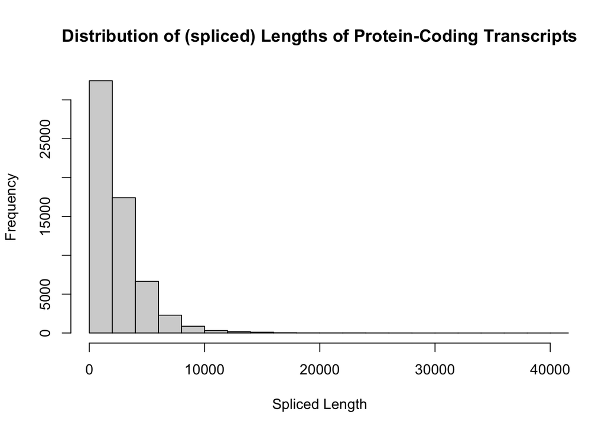

```r
hist(lengthPerTx, breaks = 50, xlim = c(0, 40000), main = "Distribution of (spliced) Lengths of Protein-Coding Transcripts", xlab = "Spliced Length", ylab = "Frequency")
```